# Plots in Comparison of platforms for testing antibodies to Chlamydia trachomatis antigens: data from the Democratic Republic of the Congo and Togo

Jessica Hoehner

Last compiled 04 January, 2021

## Where do our data come from?

The data in our sample come from communities in the Democratic Republic of the Congo (DRC) and the Togolese Republic (Togo).

Here we use `tmap` to create an interactive map with the DRC in blue and Togo in dark green. To make this plot more accessible to all users, we have chosen color-blind friendly shades of these colors and style options for the map overall using colorbrewer2.org and options available in `tmap`.

```r
tmap_mode("view")
data("World")

Africa = World[World$continent == "Africa", ]

tm_shape(Africa) +
  tm_polygons() +
  tm_shape(World, filter = World$name == "Dem. Rep. Congo" | World$name == "Togo") +
  tmap_options(max.categories = 2) +
  tm_polygons("name", palette = c("#4575b4", "#006837"), legend.show = FALSE) +
  tm_style("col_blind")
```

[interactive chart not shown]

## Figure 2: Age vs Antibody Titre

Here is an example of the plot created using `ggplot2` and data from Manono, DRC and Keran, Togo for the antibody response to the immunodominant antigen produced during infection with *Chlamydia* *trachomatis*, PgP3, measured by Multiplex Bead Assay (MBA).

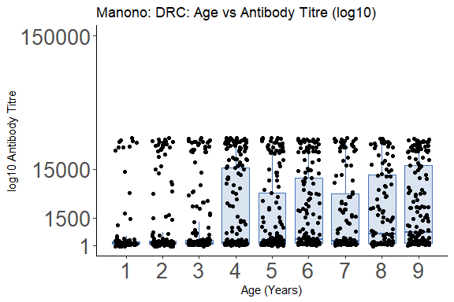

```r
ggplot(titre_df_drc, aes(age, titre, group = age)) +
  geom_boxplot(aes(age, titre),
    color = "#4575b4",
    fill = "#4575b4",
    alpha = 0.2,
    outlier.colour = "white") +
  theme_classic() +
  geom_jitter(
    na.rm = FALSE,
    width = 0.3) +
  scale_x_continuous(breaks = c(1, 2, 3, 4, 5, 6, 7, 8, 9)) +
  scale_y_log10(
    breaks = c(1, 1500, 15000, 150000),
    labels = c(1, 1500, 15000, 150000),
    limits = c(1, 150000)) +
  xlab("Age (Years)") +
  ylab("log10 Antibody Titre") +
  ggtitle("Manono: DRC: Age vs Antibody Titre (log10)") +
  coord_trans(y = scales::exp_trans()) +
  theme(
    axis.text.x = element_text(size = 20),
    axis.text.y = element_text(size = 20))
```

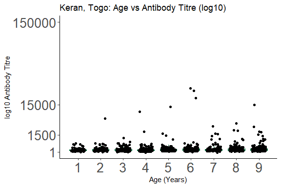

```r
ggplot(titre_df_togo, aes(age, titre, group = age)) +
  geom_boxplot(aes(age, titre),
    color = "#006837",
    fill = "#006837",
    alpha = 0.2,
    outlier.colour = "white") +
  theme_classic() +
  geom_jitter(
    na.rm = FALSE,
    width = 0.3) +
  scale_x_continuous(breaks = c(1, 2, 3, 4, 5, 6, 7, 8, 9)) +
  scale_y_log10(
    breaks = c(1, 1500, 15000, 150000),
    labels = c(1, 1500, 15000, 150000),
    limits = c(1, 150000)) +
  xlab("Age (Years)") +
  ylab("log10 Antibody Titre") +
  ggtitle("Keran, Togo: Age vs Antibody Titre (log10)") +
  coord_trans(y = scales::exp_trans()) +
  theme(
    axis.text.x = element_text(size = 20),
    axis.text.y = element_text(size = 20))
```

## Figure 3: Age vs Seroconversion Rate (SCR) Estimates and Observed Seroprevalence

Using `ggplot2`and data from the same communities as above, we can also examine the relationship between observed seroprevalence in each age group, estimates of median SCR, and age.

The points represent the median seroprevalence observed within each age group, the solid line represents the estimated median SCR by age, and the light bands around the line and points represent the 95% credible intervals around the estimates of SCR.

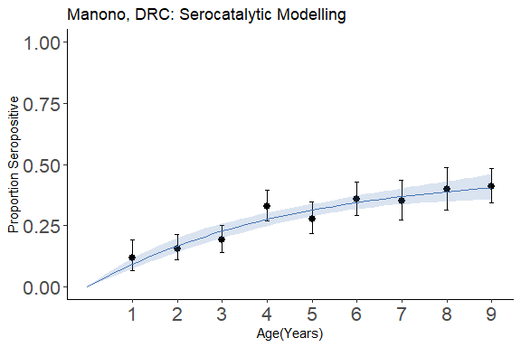

```r
ggplot(plot_df_drc, aes(age, med, age_bins_mid)) +
  geom_pointrange(aes(
    ymin = low_95,
    ymax = high_95)) +
  geom_errorbar(aes(
    ymin = low_95,
    ymax = high_95),
  colour = "black",
  width = .1,) +
  geom_line(aes(age_seq, medest),
    color = "#4575b4",) +
  geom_ribbon(aes(age_seq,
    ymin = low95_est,
    ymax = high95_est ),
  fill = "#4575b4",
  alpha = 0.2) +
  theme_classic() +
  ylim(0, 1.0) +
  xlab("Age(Years)") +
  ylab("Proportion Seropositive") +
  ggtitle("Manono, DRC: Serocatalytic Modelling") +
  scale_x_continuous(breaks = c(1, 2, 3, 4, 5, 6, 7, 8, 9)) +
  theme(
    axis.text.x = element_text(size = 16),
    axis.text.y = element_text(size = 16))
```

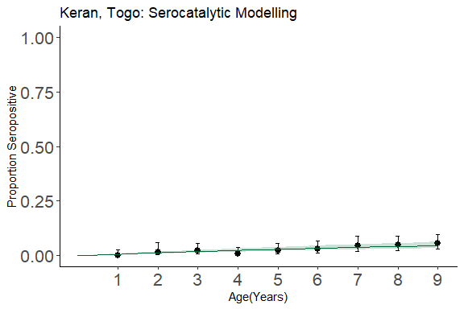

```r
ggplot(plot_df_togo, aes(age, med, age_bins_mid)) +
  geom_pointrange(aes(
    ymin = low_95,
    ymax = high_95)) +
  geom_errorbar(aes(
    ymin = low_95,
    ymax = high_95),
  colour = "black",
  width = .1, ) +
  geom_line(aes(age_seq, medest),
    color = "#006837",) +
  geom_ribbon(aes(age_seq,
    ymin = low95_est,
    ymax = high95_est),
  fill = "#006837",
  alpha = 0.2) +
  theme_classic() +
  ylim(0, 1.0) +
  xlab("Age(Years)") +
  ylab("Proportion Seropositive") +
  ggtitle("Keran, Togo: Serocatalytic Modelling") +
  scale_x_continuous(breaks = c(1, 2, 3, 4, 5, 6, 7, 8, 9)) +
  theme(
    axis.text.x = element_text(size = 16),
    axis.text.y = element_text(size = 16))
```